# week08 - answer

```python
print('hello world')
```

```
hello world
```

获取html

```python
from urllib.request import urlopen
html = urlopen("https://baike.baidu.com/item/%E7%BD%91%E7%BB%9C%E7%88%AC%E8%99%AB/5162711")
print(html)
# print(html.read())
# print(html.read().decode('utf-8'))
```

```
<http.client.HTTPResponse object at 0x000001E55F257208>
```

使用requests提交http请求

```python
import requests

# get
print(requests.get('https://uland.taobao.com/sem/tbsearch?keyword=手机').url)

param = {'q':'网络爬虫'}
print(requests.get('https://cn.bing.com/search', params=param).url)
```

```
https://uland.taobao.com/sem/tbsearch?keyword=%E6%89%8B%E6%9C%BA
https://cn.bing.com/search?q=%E7%BD%91%E7%BB%9C%E7%88%AC%E8%99%AB
```

```python
import json
# post

headers={'User-Agent':'Mozilla/5.0 (Windows NT 10.0; Win64; x64) AppleWebKit/537.36 (KHTML, like Gecko) Chrome/100.0.4896.75 Safari/537.36'}

# url='https://fanyi.baidu.com/sug'
# data = {'kw':'data'}
# response = requests.post(url=url,data=data,headers=headers)
# print(response.json())

data = {'query':'python requests post'}
# data = {'query':'товарищи'}
lan = requests.post(url='https://fanyi.baidu.com/langdetect',data=data,headers=headers).json()['lan']
url = "https://fanyi.baidu.com/v2transapi?from=%s&to=zh"%lan
response = requests.post(url=url,data=data,headers=headers)
print(response.json())
```

```
{'errno': 997, 'errmsg': '未知错误', 'query': 'python requests post', 'from': 'en', 'to': 'zh', 'error': 997}
```

BeautifulSoup

```python
# html 例子
html = """
<html><head><title>The Dormouse's story</title></head>
<body>
<p class="title" name="dromouse"><b>The Dormouse's story</b></p>
<p class="story">Once upon a time there were three little sisters; and their names were
<a href="http://example.com/elsie" class="sister" id="link1"><!-- Elsie --></a>,
<a href="http://example.com/lacie" class="sister" id="link2">Lacie</a> and
<a href="http://example.com/tillie" class="sister" id="link3">Tillie</a>;
and they lived at the bottom of a well.</p>
<p class="story">...</p>
"""
```

BeautifulSoup将复杂HTML文档转换成一个复杂的树形结构，每个节点都是Python对象，所有对象可以归纳为4种:

- Tag
- NavigableString
- BeautifulSoup
- Comment

HTML中的一个个标签(Tag)

> $<title>The Dormouse's story</title>$

上面的 title, a 等等HTML标签加上里面包括的内容就是`Tag`

```python
from bs4 import BeautifulSoup
soup = BeautifulSoup(html, features='html.parser') # 也可使用lxml，更快，但需要另外安装
print(soup.prettify())
```

```
<html>
 <head>
  <title>
   The Dormouse's story
  </title>
 </head>
 <body>
  <p class="title" name="dromouse">
   <b>
    The Dormouse's story
   </b>
  </p>
  <p class="story">
   Once upon a time there were three little sisters; and their names were
   <a class="sister" href="http://example.com/elsie" id="link1">
    <!-- Elsie -->
   </a>
   ,
   <a class="sister" href="http://example.com/lacie" id="link2">
    Lacie
   </a>
   and
   <a class="sister" href="http://example.com/tillie" id="link3">
    Tillie
   </a>
   ;
and they lived at the bottom of a well.
  </p>
  <p class="story">
   ...
  </p>
 </body>
</html>
```

```python
print(soup.title)    # 查找的是在所有内容中的第一个符合要求的标签
print(soup.a)
print(soup.p)
```

```
<title>The Dormouse's story</title>
<a class="sister" href="http://example.com/elsie" id="link1"><!-- Elsie --></a>
<p class="title" name="dromouse"><b>The Dormouse's story</b></p>
```

```python
print(soup.title.name)
print(soup.p.attrs)
print(soup.p['class'])
```

```
title
{'class': ['title'], 'name': 'dromouse'}
['title']
```

通过BeautifulSoup解析CSS

```python
css_soup = BeautifulSoup('<p class="body strikeout"></p>')
print(css_soup.p['class'])    # 一个tag可以有多个CSS的class

css_soup = BeautifulSoup('<p class="body"></p>')
print(css_soup.p['class'])
```

```
['body', 'strikeout']
['body']
```

得到了标签的内容后，用`.string`即可获取标签内部的文字。它的类型就是`NavigableString`

```python
print(soup.p.string)
print(type(soup.p.string))
# get_text()方法也可以得到标签内部的文本内容
print(soup.p.get_text())
```

```
The Dormouse's story
<class 'bs4.element.NavigableString'>
The Dormouse's story
```

Comment

```python
print(soup.a)
print(soup.a.string)
print(type(soup.a.string))
# .string方法，对任何标签都能获得其中注释的内容，即Elsie，但get_text()返回空白
print(f'from get_text() method:{soup.a.get_text()}|||')
print(soup.a.prettify()) #当它出现在HTML文档中时，Comment对象会使用特殊的格式输出
```

```
<a class="sister" href="http://example.com/elsie" id="link1"><!-- Elsie --></a>
 Elsie
<class 'bs4.element.Comment'>
from get_text() method:|||
<a class="sister" href="http://example.com/elsie" id="link1">
 <!-- Elsie -->
</a>
```

find 返回第一个符合条件的tag  
find_all 返回所有符合条件的tag

```python
soup.find('a')
```

```
<a class="sister" href="http://example.com/elsie" id="link1"><!-- Elsie --></a>
```

```python
soup.find_all('a')
```

```
[<a class="sister" href="http://example.com/elsie" id="link1"><!-- Elsie --></a>,
 <a class="sister" href="http://example.com/lacie" id="link2">Lacie</a>,
 <a class="sister" href="http://example.com/tillie" id="link3">Tillie</a>]
```

```python
# 也可传入方法
def has_class_but_no_id(tag):
    return tag.has_attr('class') and not tag.has_attr('id')

soup.find_all(has_class_but_no_id) # length=3
```

```
[<p class="title" name="dromouse"><b>The Dormouse's story</b></p>,
 <p class="story">Once upon a time there were three little sisters; and their names were
 <a class="sister" href="http://example.com/elsie" id="link1"><!-- Elsie --></a>,
 <a class="sister" href="http://example.com/lacie" id="link2">Lacie</a> and
 <a class="sister" href="http://example.com/tillie" id="link3">Tillie</a>;
 and they lived at the bottom of a well.</p>,
 <p class="story">...</p>]
```

```python
# 指定参数搜索
print(soup.find_all(id='link2'))
soup.find_all("a", class_="sister")    # class是Python的关键词。加个下划线就可以解决
```

```
[<a class="sister" href="http://example.com/lacie" id="link2">Lacie</a>]
```

```
[<a class="sister" href="http://example.com/elsie" id="link1"><!-- Elsie --></a>,
 <a class="sister" href="http://example.com/lacie" id="link2">Lacie</a>,
 <a class="sister" href="http://example.com/tillie" id="link3">Tillie</a>]
```

通过BeautifulSoup解析百度百科

```python
html = urlopen("https://baike.baidu.com/item/%E7%BD%91%E7%BB%9C%E7%88%AC%E8%99%AB/5162711").read().decode('utf-8')
soup = BeautifulSoup(html, features='html.parser')
print(soup.h1)

# all_link = soup.find_all('a')
# # print(len(all_link))
# # print(all_link[:5])
# # all_link[0]['href']
# all_href = [l['href'] for l in all_link]
# all_href[:5]


# all_link = soup.find_all('a', attrs = {'href' : True})
# all_href = [l['href'] for l in all_link]
# all_href[:5]
```

```
<h1>网络爬虫</h1>
```

```python
html = urlopen("https://baike.baidu.com/item/%E7%BD%91%E7%BB%9C%E7%88%AC%E8%99%AB/5162711").read().decode('utf-8')
soup = BeautifulSoup(html, features='html.parser')
imgs = soup.find_all('img', attrs = {'data-src' : True})
imgs_src = [l['data-src'] for l in imgs]
imgs_src
```

```
['https://bkimg.cdn.bcebos.com/pic/d833c895d143ad4bef92dd7b82025aafa50f06c8?x-bce-process=image/resize,m_lfit,w_440,limit_1/format,f_auto',
 'https://bkimg.cdn.bcebos.com/pic/500fd9f9d72a605987497aa12834349b033bba34?x-bce-process=image/resize,m_lfit,w_440,limit_1/format,f_auto',
 'https://bkimg.cdn.bcebos.com/pic/b64543a98226cffc4cba2409b9014a90f703eafd?x-bce-process=image/resize,m_lfit,w_440,limit_1/format,f_auto',
 'https://bkimg.cdn.bcebos.com/pic/d6ca7bcb0a46f21fd821b546f6246b600c33ae8a?x-bce-process=image/resize,m_lfit,w_440,limit_1/format,f_auto',
 'https://bkimg.cdn.bcebos.com/pic/d1160924ab18972bd62cebdfe6cd7b899e510a94?x-bce-process=image/resize,m_lfit,w_440,limit_1/format,f_auto']
```

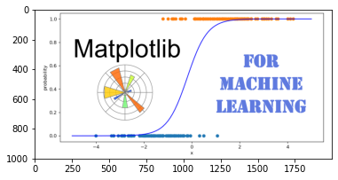

```python
import matplotlib.pyplot as plt # plt 用于显示图片
import matplotlib.image as mpimg # mpimg 用于读取图片
import numpy as np

# load
url = "https://thedatafrog.s3.amazonaws.com/media/images/matplotlib_for_ml.original.png"
img = mpimg.imread(url) # 只能读取.png文件
# 此时 img 就已经是一个 np.array 了，可以对它进行任意处理
# height, width, channel=(360, 480, 3)
h,w,c = img.shape

# show
plt.imshow(img) # 显示图片
# plt.axis('off') # 不显示坐标轴
# plt.show()

# save
# 适用于保存任何 matplotlib 画出的图像，相当于一个 screencapture
# plt.savefig('fig_cat.png')
# 也可以使用mpimg.imsave()
```

```python
html = urlopen("https://baike.baidu.com/item/%E7%BD%91%E7%BB%9C%E7%88%AC%E8%99%AB/5162711").read().decode('utf-8')
soup = BeautifulSoup(html, features='html.parser')

# 搜索class
left_dl = soup.find_all('dl', attrs = {'class': 'basicInfo-block basicInfo-left'})
# print(left_dl)
# print(left_dl[0].get_text())

names = left_dl[0].find_all('dt', attrs = {'class': 'basicInfo-item name'})
values = left_dl[0].find_all('dd', attrs = {'class': 'basicInfo-item value'})
for n in names:
    print(n.get_text())
```

```
中文名
外文名
别    名
拼    音
```

#### 练习1

爬取 `https://www.jxuspt.com/` 中所有学院中英文名称，跳转链接并格式化打印  
格式: (区块链学院/BLOCKCHAIN COLLEGE: https://www.jxuspt.com/branch/blockchain/)

爬取底部`` 创业创新``学校地图``学校公告``校园服务``党建先锋 ``一栏并格式化打印  
格式: (创业创新: http://www.jxuspt.com/Z09_ZJXY/CampusLife.htmlx)

```python
html = urlopen("https://www.jxuspt.com/").read().decode('utf-8')
soup = BeautifulSoup(html, features='html.parser')
connectL = soup.find_all("div", class_="ConnectList")
colleges = connectL[0].find_all("a", attrs = {'href' : True})
ll = []
for l in colleges:
    url = l['href']
    cn = l.find('span', class_='span1').get_text()
    en = l.find('span', class_='span2').get_text()
    ll.append(cn+r'/'+en+': '+url+' ')

links = connectL[1].find_all("a", attrs = {'href' : True})
for l in links:
    url = l['href']
    url = 'http://www.jxuspt.com'+url[1:] if url[:2] == './' else url
    cn = l.get_text().replace('\n', '').replace('\r', '').replace('\t', '').replace(' ', '')
    ll.append(cn+': '+url+' ')
ll
```

```
['区块链学院/BLOCKCHAIN COLLEGE: https://www.jxuspt.com/branch/blockchain/ ',
 '软件工程学院/SOFTWARE ENGINEERING: http://rjxy.jxuspt.com/ ',
 '网络工程学院/NETWORK ENGINEERING: https://www.jxuspt.com/branch2/ ',
 '信息技术学院/INFORMATION ENGINEERING: http://xxjsxy.jxuspt.com/ ',
 '经济管理学院/ECONOMIC MANAGEMENT: http://jgfy.jxuspt.com:8081/ ',
 'VR与艺术学院/VR AND ART COLLEGE: https://www.jxuspt.com/branch/vrart/ ',
 '新媒体学院/SCHOOL OF NEW MEDIA: https://www.jxuspt.com/branch/media/ ',
 '智能科技学院/SCHOOL OF INT SCI AND TEC: http://znkj.jxuspt.com/ ',
 '国际学院/NTERNATIONAL COLLEGE: http://international.jxuspt.com/ ',
 '创新学院/INNOVATION INSTITUTE: https://www.jxuspt.com/branch/innovate/ ',
 '继续教育学院/ONTINUING EDUCATION: https://www.jxuspt.com/branch/continuing/ ',
 '退役军人教育学院/EDUCATION FOR VETERANS: https://www.jxuspt.com/branch/ty/ ',
 '创业创新: http://www.jxuspt.com/Z09_ZJXY/CampusLife.htmlx ',
 '学校地图: http://blockchain.jxuspt.com:7569/Scan/AllMap ',
 '校友信息: http://www.jxuspt.com/Z11_XFXY/Alumnus.htmlx ',
 '学校公告: http://www.jxuspt.com/Z02_XWZX/noticebulletin.htmlx ',
 '校园服务: http://www.jxuspt.com/Z10_FWDH/ServiceEncounter.htmlx ',
 '党建先锋: https://www.jxuspt.com/partyWeb/ ']
```

#### 练习2

requests练习  
使用params，自定义淘宝搜索的物品且设置价格范围为随机数  
自定义变量word(非中英文)，并使用post提交百度翻译以判断其所属语言

```python
item='飞机'
minint = np.random.randint(10,200)
maxint = np.random.randint(minint, 9999)+1
param = {'keyword':item, 'price':'%d~%d'%(minint, maxint)}
url = requests.get('https://uland.taobao.com/sem/tbsearch', params=param).url
print(f'价格在{minint}~{maxint}范围内的{item}:\n{url} ')

word = 'despacito'
data = {'query':word}
lan = requests.post(url='https://fanyi.baidu.com/langdetect',data=data,headers=headers).json()['lan']
print(f'{word} is {lan}')
```

```
价格在57~3149范围内的飞机:
https://uland.taobao.com/sem/tbsearch?keyword=%E9%A3%9E%E6%9C%BA&price=57~3149
despacito is spa
```

#### 练习3

百度百科小练习  
从[百度百科](https://baike.baidu.com/item/%E7%99%BE%E5%BA%A6%E7%99%BE%E7%A7%91)开始爬起，随机挑选网络中的百科链接进行跳转  
标签格式为: <a target=‘blank’href="/item/%E7%99%BE%E5%BA%A6%E7%99%BE%E7%A7%91">  
跳转n次，并返回(打印)每次的访问的网页的h1标签

```python
url = 'https://baike.baidu.com/item/%E7%99%BE%E5%BA%A6%E7%99%BE%E7%A7%91'    # 百度百科
def jumpN(n=30):
    ll = []
    tmp_url = url
    for i in range(n):
        soup = BeautifulSoup(urlopen(tmp_url).read().decode('utf-8'), features='html.parser')
        print(soup.h1.get_text())
        print(tmp_url)
        ll.append(soup.h1.get_text()+': '+tmp_url)
        all_href = [l['href'] for l in soup.find_all('a', attrs = {'target': '_blank','href' : True})]
        res = []
        for l in all_href:
            if '/item/%' in l:
                res.append('https://baike.baidu.com'+l)
        tmp_url = res[np.random.randint(len(res))]
    return ll

url_hist = jumpN(20)
```

```
百度百科
https://baike.baidu.com/item/%E7%99%BE%E5%BA%A6%E7%99%BE%E7%A7%91
词媒体
https://baike.baidu.com/item/%E8%AF%8D%E5%AA%92%E4%BD%93
转型
https://baike.baidu.com/item/%E8%BD%AC%E5%9E%8B
转型
https://baike.baidu.com/item/%E8%BD%AC%E5%9E%8B/9590423
结构形态
https://baike.baidu.com/item/%E7%BB%93%E6%9E%84%E5%BD%A2%E6%80%81/5942010
百度百科：本人词条编辑服务
https://baike.baidu.com/item/%E7%99%BE%E5%BA%A6%E7%99%BE%E7%A7%91%EF%BC%9A%E6%9C%AC%E4%BA%BA%E8%AF%8D%E6%9D%A1%E7%BC%96%E8%BE%91%E6%9C%8D%E5%8A%A1/22442459?bk_fr=pcFooter
百度百科：参考资料
https://baike.baidu.com/item/%E5%8F%82%E8%80%83%E8%B5%84%E6%96%99/5718004
新华网
https://baike.baidu.com/item/%E6%96%B0%E5%8D%8E%E7%BD%91
新华通讯社
https://baike.baidu.com/item/%E6%96%B0%E5%8D%8E%E7%A4%BE/293685
贝尔格莱德
https://baike.baidu.com/item/%E8%B4%9D%E5%B0%94%E6%A0%BC%E8%8E%B1%E5%BE%B7/3185024
恶性通货膨胀
https://baike.baidu.com/item/%E6%81%B6%E6%80%A7%E9%80%9A%E8%B4%A7%E8%86%A8%E8%83%80
预算调剂
https://baike.baidu.com/item/%E9%A2%84%E7%AE%97%E8%B0%83%E8%8A%82
预算调剂
https://baike.baidu.com/item/%E9%A2%84%E7%AE%97%E8%B0%83%E8%8A%82
百度百科：本人词条编辑服务
https://baike.baidu.com/item/%E7%99%BE%E5%BA%A6%E7%99%BE%E7%A7%91%EF%BC%9A%E6%9C%AC%E4%BA%BA%E8%AF%8D%E6%9D%A1%E7%BC%96%E8%BE%91%E6%9C%8D%E5%8A%A1/22442459?bk_fr=pcFooter
百度百科：参考资料
https://baike.baidu.com/item/%E5%8F%82%E8%80%83%E8%B5%84%E6%96%99/5718004
人民网
https://baike.baidu.com/item/%E4%BA%BA%E6%B0%91%E7%BD%91
人民日报社
https://baike.baidu.com/item/%E4%BA%BA%E6%B0%91%E6%97%A5%E6%8A%A5%E7%A4%BE
瑞典
https://baike.baidu.com/item/%E7%91%9E%E5%85%B8
百度百科：本人词条编辑服务
https://baike.baidu.com/item/%E7%99%BE%E5%BA%A6%E7%99%BE%E7%A7%91%EF%BC%9A%E6%9C%AC%E4%BA%BA%E8%AF%8D%E6%9D%A1%E7%BC%96%E8%BE%91%E6%9C%8D%E5%8A%A1/22442459?bk_fr=pcFooter
百度百科：参考资料
https://baike.baidu.com/item/%E5%8F%82%E8%80%83%E8%B5%84%E6%96%99/5718004
```

#### 练习4 爬取图片

参考练习3

> 从[百度百科](https://baike.baidu.com/item/%E7%99%BE%E5%BA%A6%E7%99%BE%E7%A7%91)开始爬起，随机挑选网络中的百科链接进行跳转  
> 标签格式为: <a target=‘blank’href="/item/%E7%99%BE%E5%BA%A6%E7%99%BE%E7%A7%91">  
> 跳转n次，并返回(打印)每次的访问的网页的h1标签

每次跳转读取当前页面随机图片并打印图片链接

```python
for l in url_hist:
    title, url = l.split(': ')
    html = urlopen(url).read().decode('utf-8')
    soup = BeautifulSoup(html, features='html.parser')
    imgs = soup.find_all('img', attrs = {'data-src' : True})
    imgs_src = [l['data-src'] for l in imgs]
    img_url = imgs_src[np.random.randint(len(imgs_src))] if len(imgs_src)>0 else 'no image'
    print(f'{title}: {img_url}')
```

```
百度百科: https://bkimg.cdn.bcebos.com/pic/0eb30f2442a7d9330d9df59aad4bd11373f00125?x-bce-process=image/resize,m_lfit,h_168,limit_1/format,f_auto
词媒体: https://bkimg.cdn.bcebos.com/pic/09fa513d269759ee45c9eea2b2fb43166d22df3a?x-bce-process=image/resize,m_lfit,w_440,limit_1/format,f_auto
转型: no image
转型: no image
结构形态: no image
百度百科：本人词条编辑服务: https://bkimg.cdn.bcebos.com/pic/a686c9177f3e67097d488d6d37c79f3df9dc55dc?x-bce-process=image/resize,m_lfit,w_1280,limit_1/format,f_auto
百度百科：参考资料: https://bkimg.cdn.bcebos.com/pic/023b5bb5c9ea15ce36d3e3e4bf492df33a87e850148f?x-bce-process=image/resize,m_lfit,w_1280,limit_1/format,f_auto
新华网: https://bkimg.cdn.bcebos.com/pic/b90e7bec54e736d12f2ec0ae741a58c2d5628535c348?x-bce-process=image/resize,m_lfit,w_1280,limit_1/format,f_auto
新华通讯社: https://bkimg.cdn.bcebos.com/pic/d6ca7bcb0a46f21f638f0d1cf7246b600d33aec2?x-bce-process=image/resize,m_lfit,h_168,limit_1/format,f_auto
贝尔格莱德: https://bkimg.cdn.bcebos.com/pic/9a504fc2d56285354250075290ef76c6a7ef6315?x-bce-process=image/resize,m_lfit,w_440,limit_1/format,f_auto
恶性通货膨胀: https://bkimg.cdn.bcebos.com/pic/3b292df5e0fe9925e3d9665b34a85edf8cb171e7?x-bce-process=image/resize,m_lfit,w_278,limit_1/format,f_auto
预算调剂: no image
预算调剂: no image
百度百科：本人词条编辑服务: https://bkimg.cdn.bcebos.com/pic/0b55b319ebc4b745efc8c766c3fc1e178a821565?x-bce-process=image/resize,m_lfit,w_1280,limit_1/format,f_auto
百度百科：参考资料: https://bkimg.cdn.bcebos.com/pic/b2de9c82d158ccbf6c8107d61091ab3eb13532faeb8c?x-bce-process=image/resize,m_lfit,w_1280,limit_1/format,f_auto
人民网: https://bkimg.cdn.bcebos.com/pic/77094b36acaf2eddeae252e08d1001e9390193a3?x-bce-process=image/resize,m_lfit,w_352,limit_1/format,f_auto
人民日报社: https://bkimg.cdn.bcebos.com/pic/34fae6cd7b899e51bf2a3a1e42a7d933c8950d17?x-bce-process=image/resize,m_lfit,w_440,limit_1/format,f_auto
瑞典: no image
百度百科：本人词条编辑服务: https://bkimg.cdn.bcebos.com/pic/960a304e251f95ca11dd4b6cc5177f3e660952c4?x-bce-process=image/resize,m_lfit,w_1280,limit_1/format,f_auto
百度百科：参考资料: https://bkimg.cdn.bcebos.com/pic/023b5bb5c9ea15ce36d3e3e4bf492df33a87e850148f?x-bce-process=image/resize,m_lfit,w_1280,limit_1/format,f_auto
```